# **DA2 Term Project**

Istvan Janco #2003877

01/03/2021

## Abstract

The research is aimed to answer the question of whether and how performance metrics are affecting the salary of NBA players? The result is based on a data set of NBA salaries 1985 - 2018 and averages of player statistics (efficiency, number of games played, etc.). The main assumption is that the salaries and the performance stats are positively correlated. This analysis can be useful for general managers who are looking to extend contracts with existing players or sing new players. It suppose to provide an insight to what salary is to be expected for a player with certain characteristics and explore which players are over-valued and which players are under-valued.

## 1 Data

The data is restricted to a time frame of 2003 - 2018. The data was taken from the “data.world” website (https://data.world/datadavis/nba-salaries) and originally scraped from “basketballreference” webpage. The quality data is good, some missing values are present, however, there’s not much possibility of systematic measurement error. Apart from removing the missing values, all the players who were on a payroll for less than 5 seasons were dropped from the dataset. The aim is to deal with random extreme observations, and establish a minimum base for comparison. The aim of the model is to compare players whose salaries are different due to performance metrics not due to the lack of time spent in the NBA.  
In addition only, players who played a 100 (approx. 1 season) or more games while being under contract are qualified for the analysis. The reason is to exclude the possibility of extreme values due to lack of games played (e.g. 100% made free-throw shots over 20 games). The objective is to model average salaries on efficiency, by comparing players that are similar in some statistics but differ in terms of compensation. In order to conduct the analysis more effectively controls such as the number of games played and the draft in which a player was drafted were included. The table and figure below outlines the descriptive statistics and distributions of the aforementioned variables.

### 1.1 Variables Summary

Graph 1: Variable Summary

|  | Average salary | PER | Tot games | Draft round |
| --- | --- | --- | --- | --- |
|  | Min. : 0.4013 | Min. : 7.00 | Min. : 109.0 | Min. :1.000 |
|  | 1st Qu.: 2.5120 | 1st Qu.:12.20 | 1st Qu.: 429.2 | 1st Qu.:1.000 |
|  | Median : 4.3196 | Median :14.15 | Median : 603.0 | Median :1.000 |
|  | Mean : 5.1095 | Mean :14.52 | Mean : 624.9 | Mean :1.251 |
|  | 3rd Qu.: 7.0576 | 3rd Qu.:16.38 | 3rd Qu.: 808.5 | 3rd Qu.:1.750 |

The outcome variable is the average salary of players per career. It was scaled down by $1M. The explanatory variable is the Player Efficiency Ratio (PER) which is per minute rating that was developed to measure overall player efficiency (see Appendix 1 for more detailed description and collinearity). The control variables include the total games played for by a player for the whole career. In addition the draft round in which a player was selected is also incorporated.

### 1.2 Distribution of variables

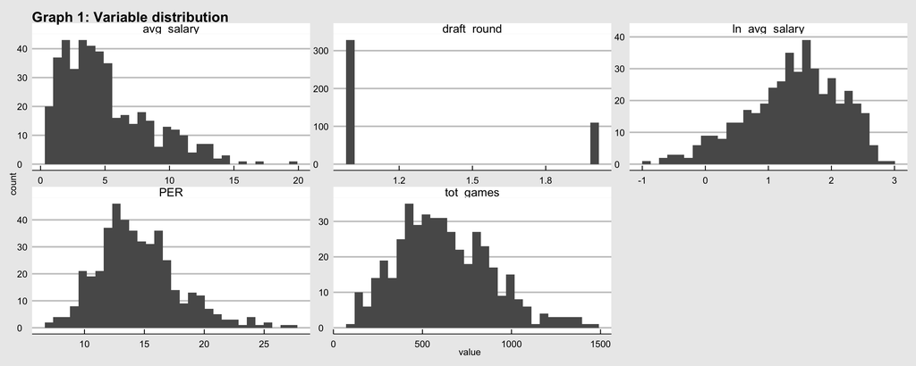

### 1.3 Transformation of Variables

Once the variables were plotted against on another using scatter plots (see Appendix 2), the below points became evident.  
1. The level-level model works best for the association between the average salary and PER. A quadratic term might be useful to capture the non-linearities, however it will complicates the interpretation. The benefit of it should be assessed relative to how complex the interpretation gets.  
2. The simple model also works best for total games played, but there’s an infection point, at about 500 games played, thus a spline with a knot at 500 can be used to tackle that issue 3. The draft round variable indicates a negative association between the draft round and average salary. The variable has only two categories thus it can be used as a dummy. The main reasons to use transformations are the following. From statistical perspective, the quadratic term for PER and linear spline for the total games played should help to offset the observed non-linear patterns. From substantive point of view, the interpretation should still be suitable for players as observations, despite introducing the quadratic term and adding a linear spline.

## 2 Model

The main aim is to regress the average NBA player salaries on player efficiency (see Appendix 2). By plotting the two variables against each other on a scatter plot, we can get a general impression of the association and the functional form.

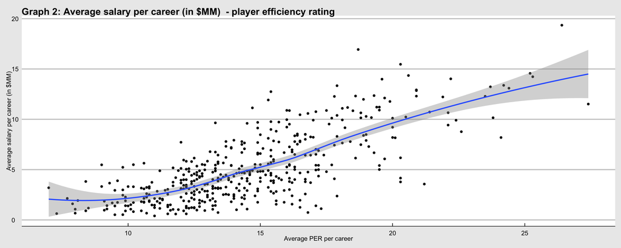

### 2.2 Residual Analysis

Largest Negative Errors

| Name | Average salary | Predicted salary | Residual |
| --- | --- | --- | --- |
| Alonzo Mourning | 3.564590 | 10.090081 | -6.525490 |
| Marreese Speights | 2.574359 | 6.993779 | -4.419421 |
| Brandan Wright | 3.776013 | 8.095254 | -4.319241 |

Largest Positive Errors

| Name | Average salary | Predicted salary | Residual |
| --- | --- | --- | --- |
| Gilbert Arenas | 13.98695 | 7.770260 | 6.216687 |
| Stephon Marbury | 16.93594 | 8.602791 | 8.333147 |
| Chandler Parsons | 11.13643 | 4.220341 | 6.916088 |

## 4 Summary

The relationship between NBA players’ salaries and Player Efficiency was investigated. Two controls were added in order to account for an athlete’s durability (Total games) and potential (Draft round). The functional form was altered using a linear spline (Total games) and a dummy variable (Draft round). Once running the model, it became evident that the continuously increasing salaries in the NBA can distort the predictions made by the model. For example, an athlete who played in the league during the beginning of the 2000s, would still get lower compensation than an athlete who competed during 2010s, even thought they can be similar on every other performance variable. There might be a possibility to offset this phenomena by applying the Purchasing Power Parity theory to the salaries and scaling them up to a reference year to normalize the value of the received compensation. These results might be useful for team managers who are trying to predict the possible market value of a prospective player.

## Appendix

### 1. Variable description

- Outcome variable: average salary of NBA players for the career.
- Explanatory variable: Player Efficiency Ratio. Is a composite rating of a player’s per-minute productivity. PER takes into account accomplishments, such as field goals, free throws, 3-pointers, assists, rebounds, blocks and steals, and negative results, such as missed shots, turnovers and personal fouls. The league average is 15.00 every season. It is important to mention that the PER might be more offense focused, thus some players who are better defenders, might be underrated.
- Control variable 1: Total games played, aiming to measure a player’s durability.
- Control variable 2: Draft round in which a player was selected. The goal of the variable is measure potential of a player to earn more.

1.1. Collinearity

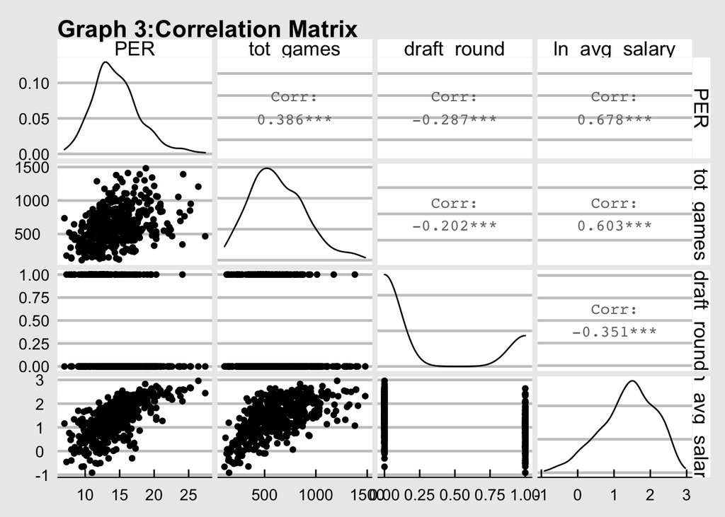

Pairwise partial correlation coefficients

|  | PER | Tot games | Draft round | PER^2 |
| --- | --- | --- | --- | --- |
| PER | 1.0000000 | -0.0395034 | -0.0705748 | 0.5782913 |
| Tot games | -0.0395034 | 1.0000000 | 0.0104785 | 0.4961110 |
| Draft round | -0.0705748 | 0.0104785 | 1.0000000 | -0.1981077 |
| PER^2 | 0.5782913 | 0.4961110 | -0.1981077 | 1.0000000 |

Overall, it looks like there in no multicollinearity in the data. However we can check the following. The matrix suggests that there might be a correlation between the PER and the number of games played: level-level model without scaling

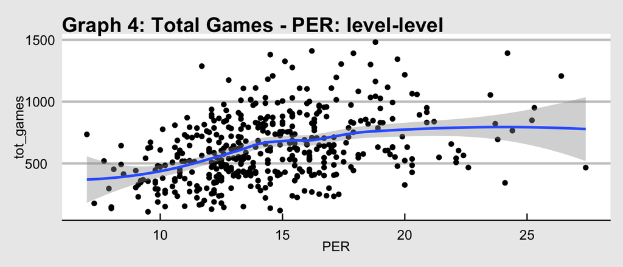

There might be a positive association between the number of games played and PER, however after PER = 14, it tends to be more and more flat. Collinearity is not expected between these variables.

We can safely assume that there is no collinearity between the draft round and the number of games played. Draft round measures the potential of a player coming to the league, while the number of games played should measure the longevity of a player. It can be affected by many other factors such as injuries

No collinearity should be assumed for draft round and PER. Draft round is reflecting the accomplishments of a player before coming to the NBA, while PER is accumulated throughout a player’s career.

## 2. Distributions based on variable transformation

2.1. **Average salary - PER: level-level model without scaling**

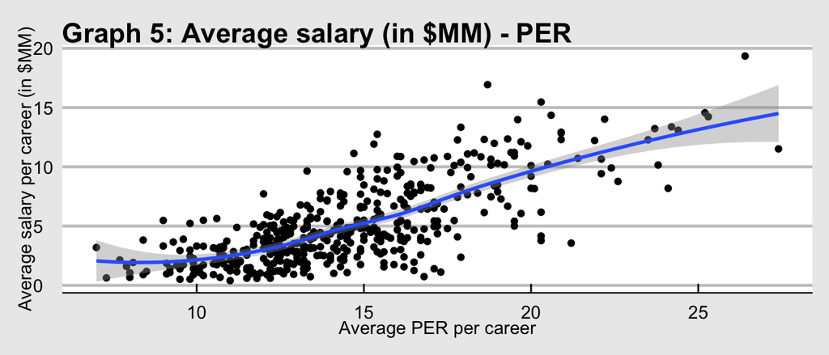

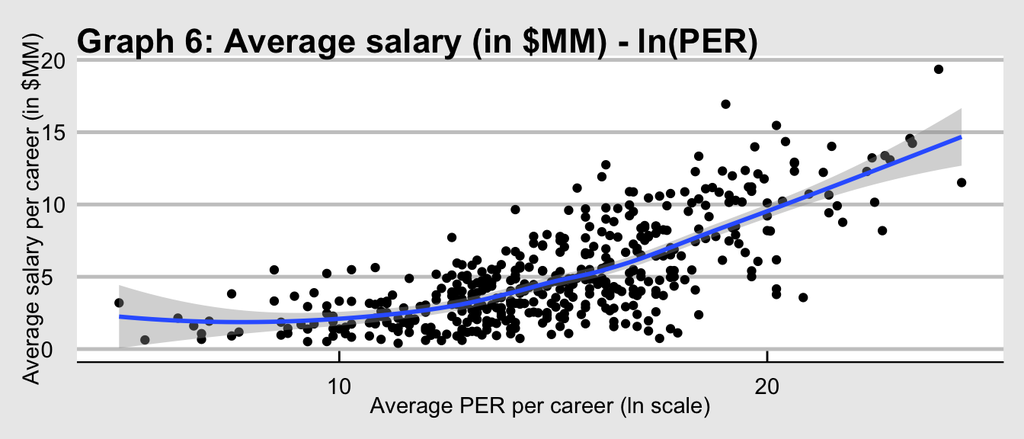

2.3. **3) ln(Average salary per career (in $MM)) - Average PER per career: log - level transformation**

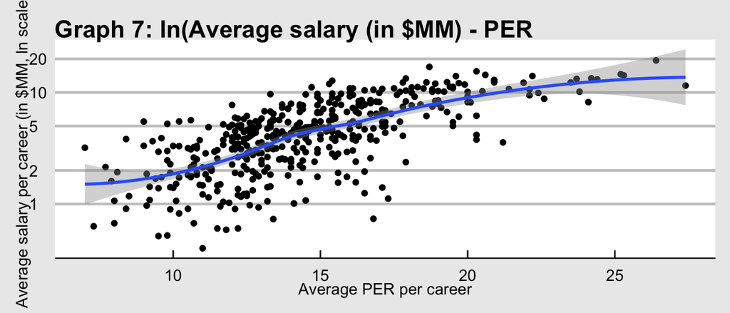

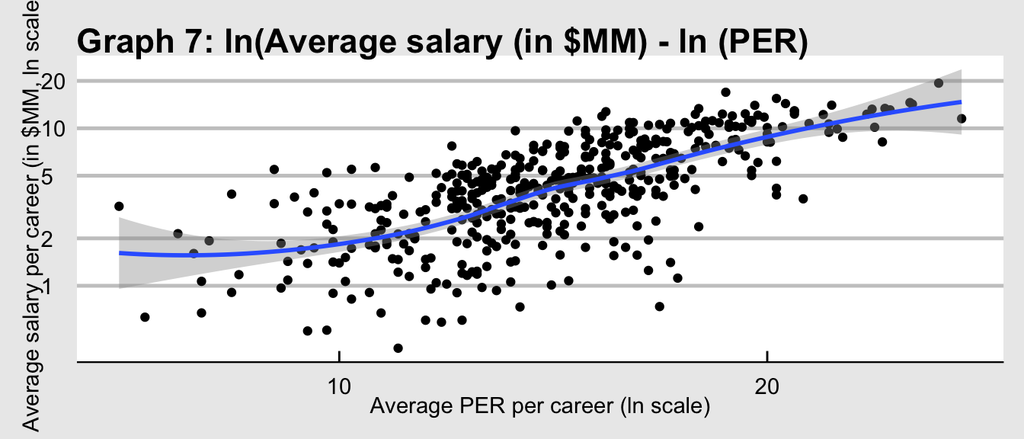

[figure not shown]

[figure not shown]

2.7. **ln(Average salary per career (in $MM)) - total games played : log - level transformation**

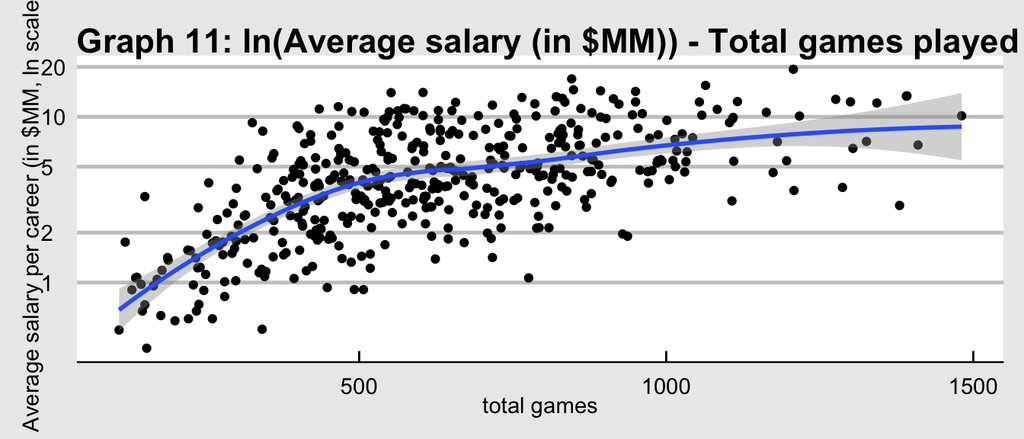

2.8. **ln(Average salary per career (in $MM)) - ln(total games played ): log log transformation**

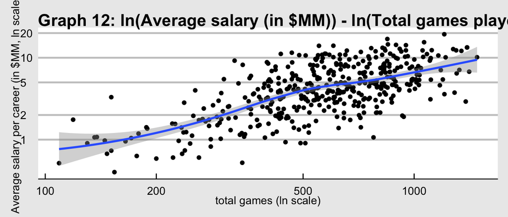

[figure not shown]

## Conclusions on varaible transformations:

1. The level-level model seems to work best for the association between the average salary and PER. A quadratic term might be useful to capture the non-linearities, however it will complicate the interpretation. The benefit of it should be assessed relative to how complex the interpretation gets.
2. The simple model also works best for total games played, but there’s an infection point, at about 500. A spline should be introduced to account for that.
3. The draft round variable indicates a negative association between the draft round and average salary. The variable can be used as a dummy.

## Reasons to use transformations

1. Statistical: the quadratic term and spline should help to offset the observed non-linear patterns. In case of PER (quadratic term addition) and total games played (linear spline)
2. Substantive: while introducing the quadratic term and adding a linear spline, the interpretation should still be suitable for players as observations.

## 3. Model fit

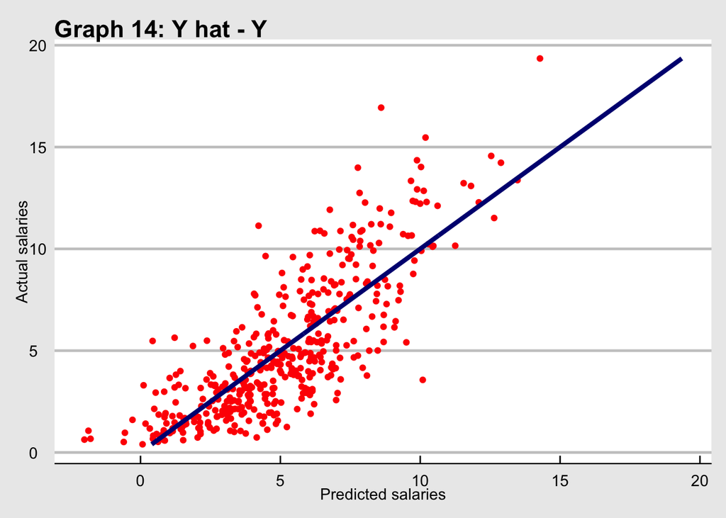

The above plot suggests that the model is fairly good in predicting salaries, however there are still some errors, which might be attributed to possible omitted variables. In addition, we can see that the model considers a number of players to be overvalued.

### 3.1. BIC and AIC measures of model fit

Bayesian Information Criterion

|  | df | BIC |
| --- | --- | --- |
| Model 3 | 4 | 1908.095 |
| Model 4 | 5 | 1908.107 |
| Model 5 | 6 | 1909.054 |

The BIC suggests that by adding variables the model models is less likely to be true.

Akaike Information Criterion

|  | df | AIC |
| --- | --- | --- |
| Model 3 | 4 | 1891.766 |
| Model 4 | 5 | 1887.696 |
| Model 5 | 6 | 1884.561 |

On the other hand the AIC decreased, once control variables were added, thus the added variables might actually be good controls.

## 4. Prediction uncertainty

### 4.1. Confidence Interval

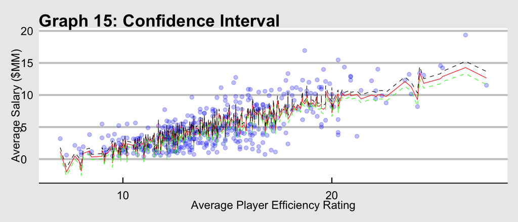

### 4.2. Prediction Interval

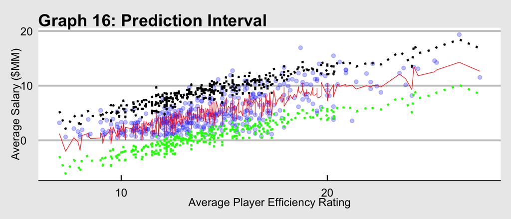

The above suggests that the model might need calibration.